# Lab 3: Dendrograms in Heatmaps, and Matrix Multiplication

Introduction to Data Mathematics 2021

Jared Gridley

In this lab you will apply what you learned in Prelab 3. This notebook includes only **Lab** sections; you were expected to complete the separate **Prelab** work before 9 am on Wednesday. Complete the quiz by 9 am Wednesday. Questions highlighted as $\color{blue}{Exercises}$ will be graded, so be sure you have answered them in your final submission! After you have completed this notebook. “Knit”" it and upload it to LMS under “Lab 3”" assignment. **Make sure that your name is at the top!** ** To get full credit on any plots, you must give them meaningful titles **

First, read in the `mtcars` dataset, which is built-in to R. Add code to scale the data and save as a matrix in mt.matrix

```r
# Insert your code here
raw.df<-mtcars

mt.matrix <- scale(raw.df)
```

Read the documentation about the dataset so you can interpret the features, for example am = 0 means the car has an automatic transmission and am = 1 means a manual transmission: https://www.rdocumentation.org/packages/datasets/versions/3.5.2/topics/mtcars

## $\color{blue}{Exercise~1}$

Create a heatmap of the *scaled* data with clustering of the rows and columns. Show the dendogram of the rows but not the columns. Do not use any of the built-in scaling functions in heatmap.2.

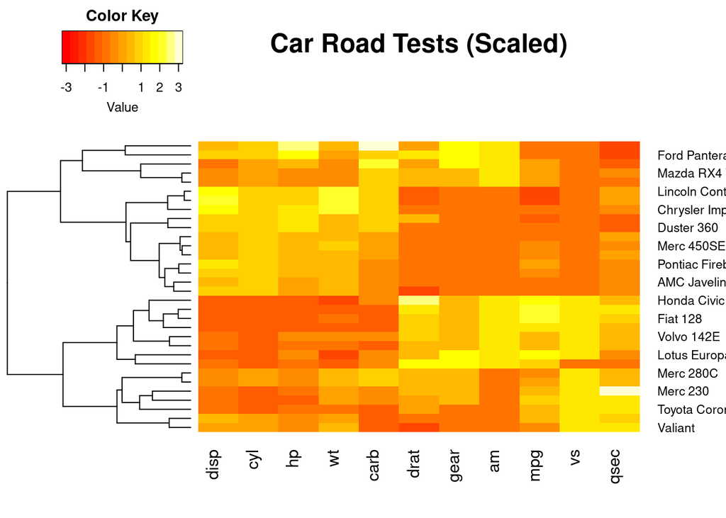

```r
# Note that the heatmap in the pdf does not show all row names, but when opened
# in a seperate browser all the names are revealed in the rows.
heatmap.2(mt.matrix,
          main = "Car Road Tests (Scaled)",
          dendrogram = "row",
          tracecol = NA,
          density.info = 'none')
```

Answer the following questions regarding the heatmap with column scaling, supposing that we cut off the dendogram at 4 clusters. Put your answer after each question.

- Describe the cluster containing the Toyota Corona? State how many cars are in it and describe in words the characteristics that define this cluster.

There are 7 cars in the cluster containing the Toyota Corona. This cluster of cars has a straight shaped engine, automatic transmission, relatively average gross horsepower. This cluster of cars was not very “peppy”, that is their average 1/4 mile time was relatively high (so slower than the other clusters), which agrees with the cluster having slightly fewer than average number of cylinders. The cars in this cluster were also slghtly above average when it came to fuel efficiency (mpg).

- Describe the cluster containing the Ferrari Dino? State how many cars are in it and describe in words the characteristics that define this cluster.

The cluster containing the Ferrari Dino has 5 cars in it. These cars are fast, as seen by their low qsec value, meaning they can travel a 1/4 mile faster than the other cars on average. The cars all had a v shaped engine and slightly below average fuel efficiency (mpg). They were all manual transmission, with an above avarage number of gears, and slightly above average rear axle ratio. They were all around the average weight for cars sampled, however they had a higher gross horsepower than other cars. This follows with their above average number of cylinders. Their displacement was average but varied between cars.

- Describe the cluster containing the Merc 450SL? State how many cars are in it and describe in words the characteristics that define this cluster.